# Using the `ForecastFramework` package to create a model

Nicholas G Reich

September 16, 2017

## Introduction to `ForecastFramework`

This document is designed as a user-friendly introduction to the `ForecastFramework` R package. The package uses [the R6 class implementation](https://www.r-project.org/nosvn/pandoc/R6.html) to design an object-oriented framework for building forecasting models for spatial time-series data. The central goals of the `ForecastFramework` package are to enable rapid model development while standardizing and simplifying implementation and, in particular, performance evaluation.

This document will focus on the functionality to design and implement a simple `ForecastModel`. However, the package has also been designed with larger-scale implementations in mind, such as the creation of a `Project` that serves as a wrapper for a particular set of evaluations on specific datasets.

## Running a `ForecastModel`

A `ForecastModel` is a class that encapsulates specific and, we believe, common types of model used to forecast from a spatio-temporal dataset. To illustrate a `ForecastModel` we will define and implement a new model class called `SARIMAModel` that inherits from forecast model. This model will be a Seasonal Auto-Regressive Integrated Moving Average (SARIMA) model, and will rely on functionality and model-fitting in the `forecast` R package.

To start, we load the package, and an R file that has code that defines our model.

```r
library(ForecastFramework)
source('models/SARIMAModel.R')
```

We will look in detail at this model file later to see how a model is actually defined, but for now all you need to know is that by sourcing that file, we have created a new class of model that can be run. We only need to specify two pieces of information to build our SARIMA model. First, we need to know the seasonal periodicity of our data. For our example, we know the periodicity is 26, that is, the data will be observed at two-week intervals and we assume that there is annual patterns in our data. Second, our SARIMA model will create forecasts by empirically simulating possibly observed values for each time step. We need to tell the models how many simulations to make (the `nsim` parameter).

```r
nsim <- 1000
sarima_model <- SARIMAModel$new(period = 26, nsim=nsim)
```

So now we’ve instantiated a new SARIMA model using a call to our model class `SARIMAModel` and using the `$new` method. Notice that there is no data or model-fitting involved yet. So let’s get on to the fun part. We have some long-format data on dengue hemorrhagic fever incidence at the province-level in Thailand.

```r
dat <- read.csv('data/province-biweek-counts.csv')
head(dat)
```

```
##   province year biweek  date_sick cases
## 1       10 2006      1 2006-01-01   265
## 2       10 2006      2 2006-01-15   162
## 3       10 2006      3 2006-01-29   211
## 4       10 2006      4 2006-02-12   113
## 5       10 2006      5 2006-02-26   165
## 6       10 2006      6 2006-03-12   146
```

Now, `ForecastModels` only have specific types of data that they know how to handle. An `IncidenceMatrix` is one such class of data. An incidence matrix represents spatial time-series data in a matrix with one row per location and one column per time. Every value in the matrix represents the observed data for that location and time. So, we have to take our long-format incidence data and transform or “recast” it into a wide data format. We also add 1 to all of the counts to avoid strangeness with zeroes in the SARIMA fits. Notice that we again use the `$new` method of the `IncidenceMatrix` class to create a specific instance of this generic class.

```r
inc <- IncidenceMatrix$new(1 + reshape2::acast(dat, province~date_sick, value.var='cases'))
```

In this dataset, we have 77 unique locations (provinces). For our example, we will just choose three of them to fit.

```r
prov_nums <- c(10, 41, 50)
nmodels <- length(prov_nums)
```

Now comes the fun part, let’s fit a SARIMA model to these three provinces of interest.

```r
sarima_model$fit(inc$subset(rows = prov_nums, mutate = FALSE))
```

You’ll notice that we again used the R6 syntax for calling the `$fit` method. This was one of the functions that we defined in our `SARIMAModel.R` file. Also notice that just calling the `fit` method modifies the object, we don’t need to make any reassignments to store the new model fits.

Now let’s generate forecasts for 52 steps (that’s two years) into the future.

```r
steps <- 52
tmp <- sarima_model$forecast(steps = steps)
```

Here, we do create a new object to store the forecasts, because forecasts themselves are a different type of object than the model itself.

Now we can visualize the forecasts. The median forecast is the dark black line with the 10th and 90th percentiles of the forecasts shown in blue. The observed data is the thin black line.

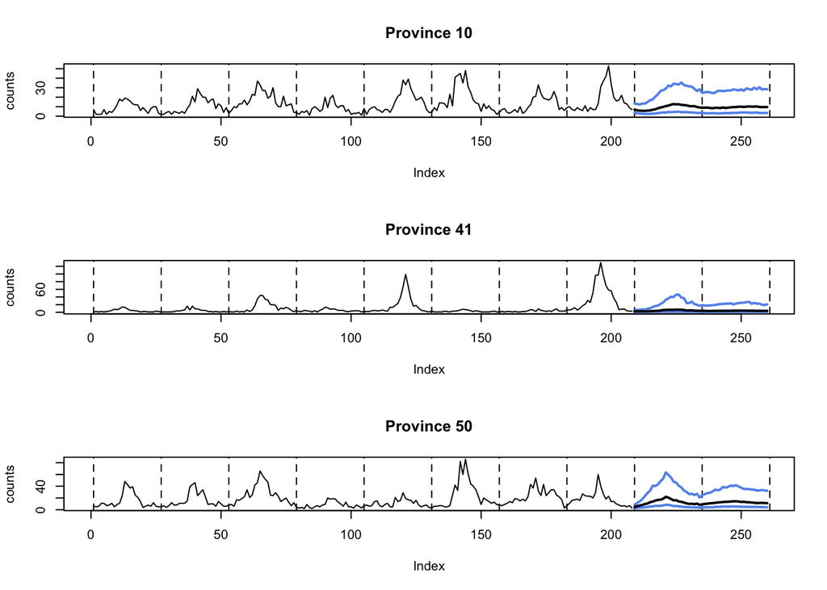

```r
par(mfrow=c(3,1))
for(row_idx in 1:nmodels){
    ntimes <- inc$ncol
    plot(inc$mat[prov_nums[row_idx],], type="l",
         xlim=c(0, ntimes+steps), ylim = range(inc$mat[prov_nums[row_idx],]),
         ylab="counts", main = paste("Province", prov_nums[row_idx]))
    abline(v=seq(1, 350, by=26), lty=2)
    lines((ntimes+1):(ntimes+steps), tmp$quantile(.1)$mat[row_idx,], lwd=2, col="cornflowerblue")
    lines((ntimes+1):(ntimes+steps), tmp$quantile(.9)$mat[row_idx,], lwd=2, col="cornflowerblue")
    lines((ntimes+1):(ntimes+steps), tmp$median()$mat[row_idx,], lwd=2)
}
```

## Building a `ForecastModel`

Here, we will unpack the specific parts of a `ForecastModel` definition.